# OBJECTIF 3 : Accessibilité avec R et Open Street Map

## (4) CARTOGRAPHIE D’ISOCHRONES

### Exemple de Bouaké

On commence par repérer les coordonnées les plus exactes possibles du marché de Bouaké en se servant par exemple de Google Maps. Puis on va utiliser soit la fonction `osrmIsochrone()`, soit la fonction `osrmIsodistance()` du package **osrm**pour générer des polygones correspondant aux points situés respectivement à une même distance en temps ou une même distance en kilomètres par la route.

```r
iso_time <- osrmIsochrone(loc = c(-5.02483,7.69714),
                                 breaks = c(0,30,60,90,120,150,180, 210, 240)
                                 )
iso_time$isomean=(iso_time$isomin+iso_time$isomax)/120
iso_time_proj<-st_transform(iso_time, crs=2043)


iso_dist <- osrmIsodistance(loc = c(-5.02483,7.69714),
                                 breaks = c(0,30000,60000,90000,120000,150000, 180000, 210000, 240000))
iso_dist$isomean=(iso_dist$isomin+iso_dist$isomax)/2000
iso_dist_proj<-st_transform(iso_dist, crs=2043)
```

On peut maintenant tracer deux cartes d’isolignes, l’une correspondant aux temps et l’autre aux distances :

```r
png("data/exo_access/bouake.png", width=1000, height=500)
par(mfrow=c(1,2))
### Distance kilométrique
mf_theme(x = "agolalight")

mf_map(map_districts_proj,
       col="gray90",
       border="gray50",
       lwd=1)


mf_map(iso_dist_proj,
       type="choro",
       var="isomean",
       nbreaks=8,
       leg_title = "distance (km)",
       leg_val_rnd = 0,
      border=NA,
       add=T)

mf_map(map_districts_proj,
       col=NA,
       border="gray50",
       lwd=1,
       add=T)

mf_map(map_roads_proj,
       var = "niveau",
       lwd= map_roads_proj$size,
       col="yellow",
       add=T)

mf_map(map_districts_chef_proj,
       pch= 20,
       col="red",
       border="yellow",
       lwd=1,
       cex = 1.3,
       add=T)

mf_label(map_districts_chef_proj,
         var = "DIS_CTR",
         col = "black",cex = 0.5, overlap = F)


mf_layout(title = "Distance kilométrique ",
          credits = "Grasland C. & Vakaramoko B., EE CIST 2023",
          frame = T,scale = T, arrow = F)



#### Distance temps
mf_theme(x = "agolalight")

mf_map(map_districts_proj,
       col="gray90",
       border="gray50",
       lwd=1)


mf_map(iso_time_proj,
       type="choro",
       var="isomean",
       breaks=c(0,0.501,1.001,1.5001,2.001,2.5001,3.001,3.5001,4.001),
   #    nbreaks=8,
       leg_title = "temps (heures)",
       leg_val_rnd = 1,
      border=NA,
       add=T)

mf_map(map_districts_proj,
       col=NA,
       border="gray50",
       lwd=1,
       add=T)

mf_map(map_roads_proj,
       var = "niveau",
       lwd= map_roads_proj$size,
       col="yellow",
       add=T)

mf_map(map_districts_chef_proj,
       pch= 20,
       col="red",
       border="yellow",
       lwd=1,
       cex = 1.3,
       add=T)

mf_label(map_districts_chef_proj,
         var = "DIS_CTR",
         col = "black",cex = 0.5, overlap = F)


mf_layout(title = "Distance temps ",
          credits = "Grasland C. & Vakaramoko B., EE CIST 2023",
          frame = T,scale = T, arrow = F)

dev.off()
```

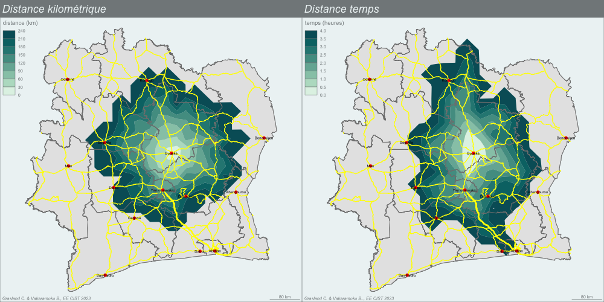

- **Commentaire** : La zone accessible en mois de 240 km recouvre l’essentiel de la partie centrale du pays et affiche une forme globalement circulaire en raison de la situation de carrefour de Bouaké. Mais la zone accessible en mois de 4 h est davantage allongé dans le sens Nord-Sud en raison de la présence d’autoroutes ou de voies rapides sur l’axe Abidjan-Yamoussoukro-Korhogo. Evidemment ces calculs théoriques ne tiennent pas compte des barrages et des “corps habillés” …

### Exemple d’Abidjan

A titre de comparaison, on refait le même exercice pour Abidjan en prenant comme point de départ le Plateau.

```r
iso_time <- osrmIsochrone(loc = c(-4.02044,5.32374),
                                 breaks = c(0,30,60,90,120,150,180, 210, 240)
                                 )
iso_time$isomean=(iso_time$isomin+iso_time$isomax)/120
iso_time_proj<-st_transform(iso_time, crs=2043)


iso_dist <- osrmIsodistance(loc = c(-4.02044,5.32374),
                                 breaks = c(0,30000,60000,90000,120000,150000, 180000, 210000, 240000))
iso_dist$isomean=(iso_dist$isomin+iso_dist$isomax)/2000
iso_dist_proj<-st_transform(iso_dist, crs=2043)


png("data/exo_access/abidjan.png", width=1000, height=500)
par(mfrow=c(1,2))
### Distance kilométrique
mf_theme(x = "agolalight")

mf_map(map_districts_proj,
       col="gray90",
       border="gray50",
       lwd=1)


mf_map(iso_dist_proj,
       type="choro",
       var="isomean",
       nbreaks=8,
       leg_title = "distance (km)",
       leg_val_rnd = 0,
      border=NA,
       add=T)

mf_map(map_districts_proj,
       col=NA,
       border="gray50",
       lwd=1,
       add=T)

mf_map(map_roads_proj,
       var = "niveau",
       lwd= map_roads_proj$size,
       col="yellow",
       add=T)

mf_map(map_districts_chef_proj,
       pch= 20,
       col="red",
       border="yellow",
       lwd=1,
       cex = 1.3,
       add=T)

mf_label(map_districts_chef_proj,
         var = "DIS_CTR",
         col = "black",cex = 0.5, overlap = F)


mf_layout(title = "Distance kilométrique ",
          credits = "Grasland C. & Vakaramoko B., EE CIST 2023",
          frame = T,scale = T, arrow = F)



#### Distance temps
mf_theme(x = "agolalight")

mf_map(map_districts_proj,
       col="gray90",
       border="gray50",
       lwd=1)


mf_map(iso_time_proj,
       type="choro",
       var="isomean",
       breaks=c(0,0.501,1.001,1.5001,2.001,2.5001,3.001,3.5001,4.001),
   #    nbreaks=8,
       leg_title = "temps (heures)",
       leg_val_rnd = 1,
      border=NA,
       add=T)

mf_map(map_districts_proj,
       col=NA,
       border="gray50",
       lwd=1,
       add=T)

mf_map(map_roads_proj,
       var = "niveau",
       lwd= map_roads_proj$size,
       col="yellow",
       add=T)

mf_map(map_districts_chef_proj,
       pch= 20,
       col="red",
       border="yellow",
       lwd=1,
       cex = 1.3,
       add=T)

mf_label(map_districts_chef_proj,
         var = "DIS_CTR",
         col = "black",cex = 0.5, overlap = F)


mf_layout(title = "Distance temps ",
          credits = "Grasland C. & Vakaramoko B., EE CIST 2023",
          frame = T,scale = T, arrow = F)

dev.off()
```

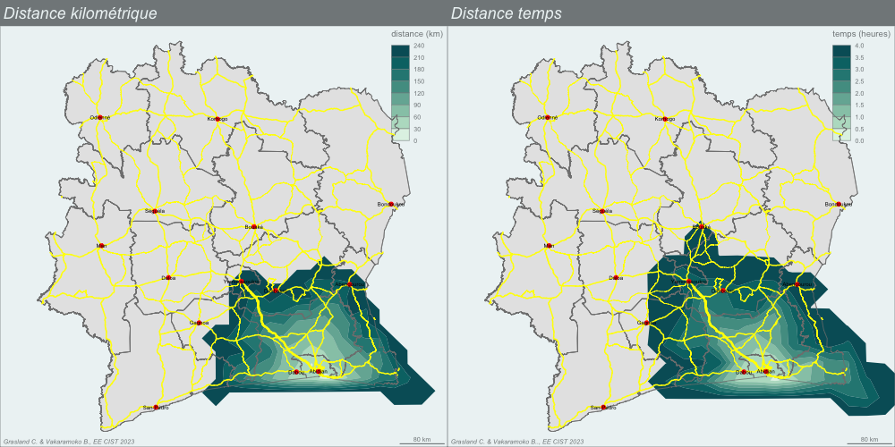

### Exemple d’Odienné

On prend maintenant le cas d’Odienné qui est l’une des villes les plus périphériques et les moins bien relié au reste du pays.

```r
iso_time <- osrmIsochrone(loc = c(-7.56400,9.50300),
                                 breaks = c(0,30,60,90,120,150,180, 210, 240)
                                 )
iso_time$isomean=(iso_time$isomin+iso_time$isomax)/120
iso_time_proj<-st_transform(iso_time, crs=2043)


iso_dist <- osrmIsodistance(loc = c(-7.56400,9.50300),
                                 breaks = c(0,30000,60000,90000,120000,150000, 180000, 210000, 240000))
iso_dist$isomean=(iso_dist$isomin+iso_dist$isomax)/2000
iso_dist_proj<-st_transform(iso_dist, crs=2043)


png("data/exo_access/odienne.png", width=1000, height=500)
par(mfrow=c(1,2))
### Distance kilométrique
mf_theme(x = "agolalight")

mf_map(map_districts_proj,
       col="gray90",
       border="gray50",
       lwd=1)


mf_map(iso_dist_proj,
       type="choro",
       var="isomean",
       nbreaks=8,
       leg_title = "distance (km)",
       leg_val_rnd = 0,
      border=NA,
       add=T)

mf_map(map_districts_proj,
       col=NA,
       border="gray50",
       lwd=1,
       add=T)

mf_map(map_roads_proj,
       var = "niveau",
       lwd= map_roads_proj$size,
       col="yellow",
       add=T)

mf_map(map_districts_chef_proj,
       pch= 20,
       col="red",
       border="yellow",
       lwd=1,
       cex = 1.3,
       add=T)

mf_label(map_districts_chef_proj,
         var = "DIS_CTR",
         col = "black",cex = 0.5, overlap = F)


mf_layout(title = "Distance kilométrique ",
          credits = "Grasland C. & Vakaramoko B., EE CIST 2023",
          frame = T,scale = T, arrow = F)



#### Distance temps
mf_theme(x = "agolalight")

mf_map(map_districts_proj,
       col="gray90",
       border="gray50",
       lwd=1)


mf_map(iso_time_proj,
       type="choro",
       var="isomean",
       breaks=c(0,0.501,1.001,1.5001,2.001,2.5001,3.001,3.5001,4.001),
   #    nbreaks=8,
       leg_title = "temps (heures)",
       leg_val_rnd = 1,
      border=NA,
       add=T)

mf_map(map_districts_proj,
       col=NA,
       border="gray50",
       lwd=1,
       add=T)

mf_map(map_roads_proj,
       var = "niveau",
       lwd= map_roads_proj$size,
       col="yellow",
       add=T)

mf_map(map_districts_chef_proj,
       pch= 20,
       col="red",
       border="yellow",
       lwd=1,
       cex = 1.3,
       add=T)

mf_label(map_districts_chef_proj,
         var = "DIS_CTR",
         col = "black",cex = 0.5, overlap = F)


mf_layout(title = "Distance temps ",
          credits = "Grasland C. & Vakaramoko B., EE CIST 2023",
          frame = T,scale = T, arrow = F)

dev.off()
```

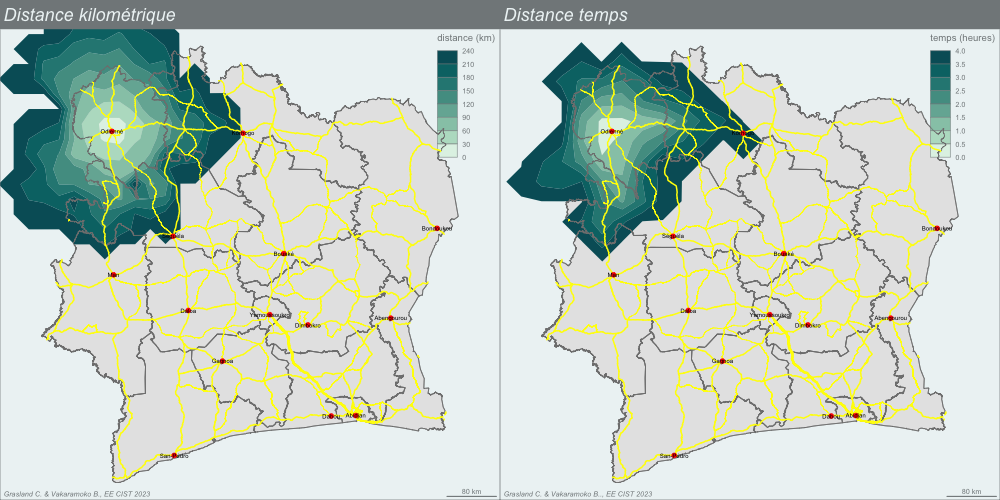

- **Commentaire** : la zone accessible en 240 km ou 4h est assez réduite à l’intérieur de la Côte d’Ivoire. Toutefois, le calcul effectué par OSRM ne se limite pas aux frontières du pays et indique une accessibilité possibles de territoires voisins situés en Guinée ou au Mali.

## CONCLUSION

L’exercice a montré que les calculs de distances routières effectuées à l’aide d’Open Street Map fournissent d’**assez bonnes approximations des distances kilométriques et des distances temps**. Les calculs sont certes moins précis que ceux que l’on peut effectuer en temps réel à l’aide de fournisseurs privés tels que Google Map. Mais ils fournissent des résultats libres de droits à partir d’une base de donnée mise à jour régulièrement par les citoyens du pays.